# HW3-Trace

Hakan Ekiz - IE48B - Fall2021

13 Aralık 2021

## Homework Information

### Distance Measurements

1- Euclidian 2- DTW (Windows size=10) 3- DTW (Window size=20) 4- ERP

### K nn classifiers

1- k=1 2- k=3 3- k=5

### Datasets

1- ECG200 2- Plane 3- SyntheticControl 4- Trace 5- SmoothSubspace

Note: Since it takes time to run 5 different datasets in the same file and convert them to reports, 5 different files will be loaded for 5 different datasets.

## Libraries and Functions

```r
require(data.table)
require(ggplot2)
require(repr)
require(rpart)
require(rattle)
require(TSrepr)
require(TSdist)
require(dtw)
require(zoo)
require(genlasso)
require(e1071)
```

```r
options(repr.plot.width=15, repr.plot.height=8)
```

```r
nn_classify_cv=function(dist_matrix,train_class,test_indices,k=1){

    test_distances_to_train=dist_matrix[test_indices,]
    test_distances_to_train=test_distances_to_train[,-test_indices]
    train_class=train_class[-test_indices]
    #print(str(test_distances_to_train))
    ordered_indices=apply(test_distances_to_train,1,order)
    if(k==1){
        nearest_class=as.numeric(trainclass[as.numeric(ordered_indices[1,])])
        nearest_class=data.table(id=test_indices,nearest_class)
    } else {
        nearest_class=apply(ordered_indices[1:k,],2,function(x) {trainclass[x]})
        nearest_class=data.table(id=test_indices,t(nearest_class))
    }

    long_nn_class=melt(nearest_class,'id')

    class_counts=long_nn_class[,.N,list(id,value)]
    class_counts[,predicted_prob:=N/k]
    wide_class_prob_predictions=dcast(class_counts,id~value,value.var='predicted_prob')
    wide_class_prob_predictions[is.na(wide_class_prob_predictions)]=0
    class_predictions=class_counts[,list(predicted=value[which.max(N)]),by=list(id)]


    return(list(prediction=class_predictions,prob_estimates=wide_class_prob_predictions))

}
```

# Trace

Train Size=100 TestSize=100 Length=275 Number of Class=4

## Data

```r
current_folder=getwd()
dataset='Trace'
main_path=sprintf('%s/ClassificationData/%s/%s',current_folder,dataset,dataset)

dist_path=sprintf('%s/ClassificationData/%s/distances/%s',current_folder,dataset,dataset)

train_data_path=sprintf('%s_TRAIN.txt',main_path)
traindata=as.matrix(fread(train_data_path))

test_data_path=sprintf('%s_TEST.txt',main_path)
testdata=as.matrix(fread(test_data_path))

#first column is the class variable
trainclass=traindata[,1] # takes -1 and 1
testclass=testdata[,1] # takes -1 and 1

#drop first column
traindata=traindata[,2:ncol(traindata)]
testdata=testdata[,2:ncol(testdata)]

# instance characteristics
tlength=ncol(traindata)
n_series_train=nrow(traindata)
n_series_test=nrow(testdata)
```

```r
head(data.table(traindata))
```

```
##            V2         V3         V4         V5         V6         V7         V8
## 1:  0.5440704  0.6578630  0.6112391  0.5454131  0.5321561  0.5930125  0.5952802
## 2:  0.7664298  0.6246319  0.7422470  0.6682216  0.7661175  0.7306850  0.6551092
## 3: -2.0450118 -2.0916771 -2.0776367 -2.0335167 -1.9901730 -2.0577092 -2.0128429
## 4: -1.7050221 -1.7391240 -1.7256591 -1.8017184 -1.7425432 -1.7603664 -1.6915715
## 5:  0.5413721  0.5719079  0.5621467  0.5209509  0.5274937  0.6040431  0.5405210
## 6: -1.2781808 -1.2707170 -1.2754118 -1.2440114 -1.2965360 -1.2243645 -1.2484483
##            V9        V10        V11        V12        V13        V14        V15
## 1:  0.5382770  0.5634290  0.5959565  0.6329149  0.5846464  0.6231872  0.6059547
## 2:  0.7293299  0.7236512  0.7028178  0.7561677  0.7004173  0.6823094  0.7089431
## 3: -2.0509702 -2.0553157 -2.0760096 -1.9999803 -2.0131392 -2.0493882 -2.0567518
## 4: -1.6875198 -1.7615121 -1.7748398 -1.7821487 -1.7649892 -1.7377334 -1.6885730
## 5:  0.5803829  0.5005821  0.5978125  0.5553183  0.5039982  0.4872150  0.5291920
## 6: -1.2160164 -1.2532291 -1.2904419 -1.2262962 -1.2746380 -1.2482585 -1.2257146
##           V16        V17        V18        V19        V20        V21        V22
```

[output cut: 272 more lines]

```r
dt_ts_train=data.table(traindata)
dt_ts_train[,id:=1:.N]
long_train=melt(dt_ts_train,id.vars=c('id'))
long_train[,time:=as.numeric(gsub("\\D", "", variable))-1]
long_train=long_train[order(id,time)]
long_train[,diff_series:=value-shift(value,1),by=list(id)]
head(long_train)
```

```
##    id variable     value time diff_series
## 1:  1       V2 0.5440704    1          NA
## 2:  1       V3 0.6578630    2  0.11379262
## 3:  1       V4 0.6112391    3 -0.04662396
## 4:  1       V5 0.5454131    4 -0.06582596
## 5:  1       V6 0.5321561    5 -0.01325704
## 6:  1       V7 0.5930125    6  0.06085644
```

```r
#head(dt_ts_train)
```

```r
dt_ts_test=data.table(testdata)
dt_ts_test[,id:=1:.N]
long_test=melt(dt_ts_test,id.vars=c('id'))
long_test[,time:=as.numeric(gsub("\\D", "", variable))-1]
long_test=long_test[order(id,time)]
long_test[,diff_series:=value-shift(value,1),by=list(id)]
head(long_test)
```

```
##    id variable     value time diff_series
## 1:  1       V2 -1.296736    1          NA
## 2:  1       V3 -1.333738    2  -0.0370024
## 3:  1       V4 -1.349496    3  -0.0157577
## 4:  1       V5 -1.318587    4   0.0309092
## 5:  1       V6 -1.307479    5   0.0111077
## 6:  1       V7 -1.255202    6   0.0522766
```

```r
#head(dt_ts_test)
```

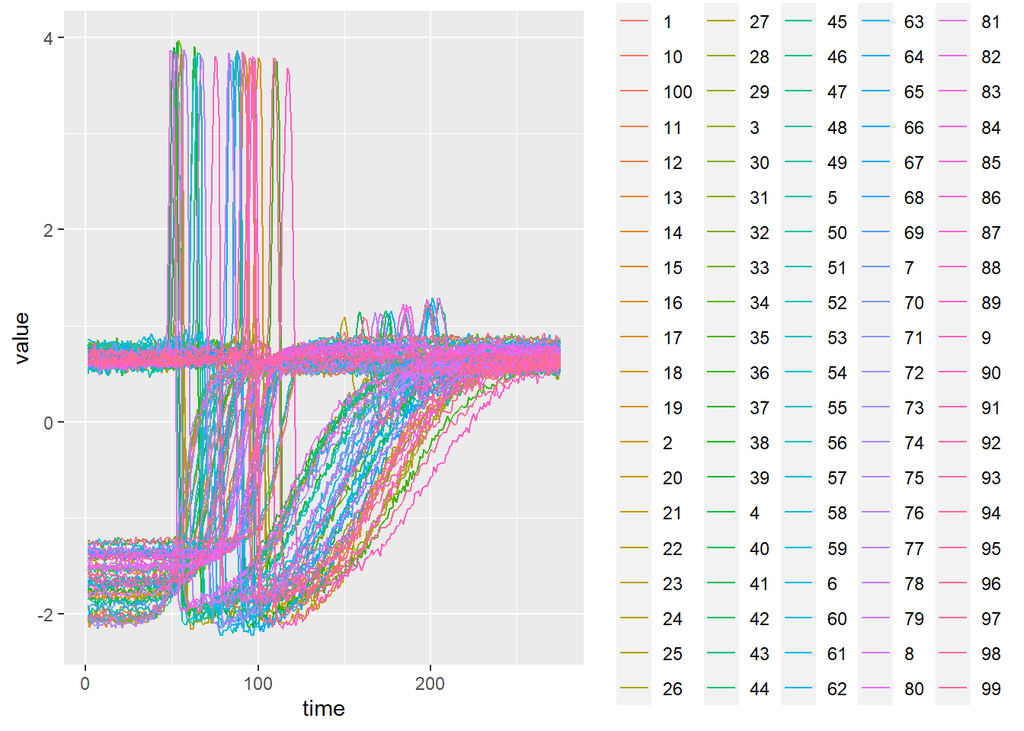

```r
ggplot(long_train, aes(time,value)) + geom_line(aes(color=as.character(id)))
```

## Representations

PAA with segmenth length = 5 PLA with n_important = 10 Tree with maxdepth = 12

```r
#Piecewise Aggregate + Piecewise Linear Approximation + Tree


segmentlength = 5
n_important = 10

long_train=long_train[order(id,time)]

treeres <- vector('list', n_series_train)
paares <- vector('list', n_series_train)

for (i in 1:n_series_train) {

  data_plot=long_train[id==i]

  data_ts=long_train[id==i]$value
  paa_rep=repr_paa(data_ts, segmentlength , meanC)
  dummy_time = c(1:(length(paa_rep)-1))*segmentlength
  dummy_time = c(dummy_time, (nrow(data_plot)))
  dt_paa = data.table(time=dummy_time, paa_rep)

  pla_rep=repr_pla(data_ts, times = n_important, return = "points")
  pla_rep=repr_pla(data_ts, times = n_important, return = "both")
  setnames(pla_rep,c('places','points'),c('time','pla_rep'))
  pla_rep$time=pla_rep$time+1


  tree=rpart(value~time,data_plot,control=rpart.control(cp=0,maxdepth=12,minsplit=20,minbucket=10))
  data_plot[,tree_rep:=predict(tree,data_plot)]


  data_plot=merge(data_plot,dt_paa,by='time',all.x=T)
  data_plot=merge(data_plot,pla_rep,by='time',all.x=T)

  data_plot[,paa_rep:=nafill(paa_rep,'nocb')]
  data_plot[, pla_rep := na.approx(pla_rep)]

  paares[[i]]=data_plot

}
results <- rbindlist(paares)
```

```r
head(results)
```

```
##    time id variable     value diff_series  tree_rep   paa_rep   pla_rep
## 1:    1  1       V2 0.5440704          NA 0.5776697 0.5781483 0.5440704
## 2:    2  1       V3 0.6578630  0.11379262 0.5776697 0.5781483 0.5454486
## 3:    3  1       V4 0.6112391 -0.04662396 0.5776697 0.5781483 0.5468268
## 4:    4  1       V5 0.5454131 -0.06582596 0.5776697 0.5781483 0.5482049
## 5:    5  1       V6 0.5321561 -0.01325704 0.5776697 0.5781483 0.5495831
## 6:    6  1       V7 0.5930125  0.06085644 0.5776697 0.5771910 0.5509613
```

Sample representaion for id=10

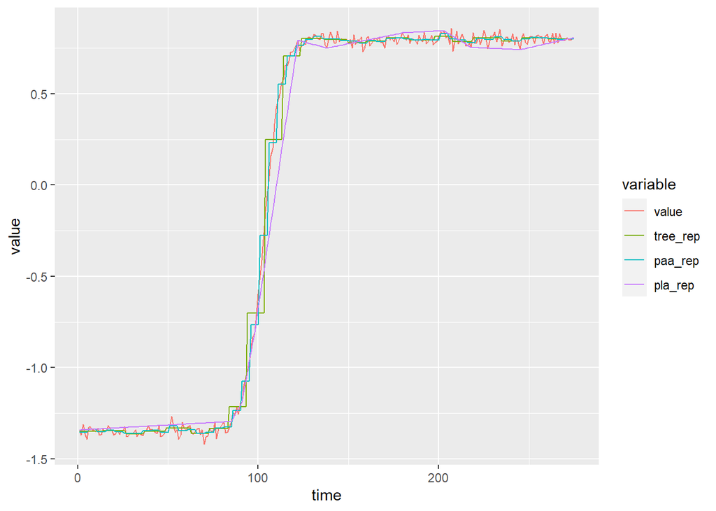

```r
selected=results[id==10]
data_show=melt(selected,id.vars='time',measure.vars=c('value','tree_rep', 'paa_rep', 'pla_rep'))
ggplot(data_show,aes(x=time,y=value,color=variable))+
    geom_line()
```

## Distance Measurement

Preliminary work with results dataset for future distance calculations;

Euc Dtw (window size = 10) Dtw (window size = 20) ERP

```r
value_train=dcast(results[!is.na(value)],id~time,value.var='value')
#head(value_train)
value_train=as.matrix(value_train)
```

```r
diff_train=dcast(results[!is.na(diff_series)],id~time,value.var='diff_series')
#head(diff_train)
diff_train=as.matrix(diff_train)
```

```r
tree_train=dcast(results[!is.na(tree_rep)],id~time,value.var='tree_rep')
#head(tree_train)
tree_train=as.matrix(tree_train)
```

```r
paa_train=dcast(results[!is.na(paa_rep)],id~time,value.var='paa_rep')
#head(paa_train)
paa_train=as.matrix(paa_train)
```

```r
pla_train=dcast(results[!is.na(pla_rep)],id~time,value.var='pla_rep')
#head(pla_train)
pla_train=as.matrix(pla_train)
```

```r
large_number=10000
```

### Euclidian

Raw, difference, tree, paa(piecewise aggregate approximation with segmenth length 5) and pla values are used.

```r
# raw + euc
dist_euc=as.matrix(dist(value_train))
diag(dist_euc)=large_number
fwrite(dist_euc,sprintf('%s_euc_raw_dist.csv',dist_path),col.names=F)
```

```
## x being coerced from class: matrix to data.table
```

```r
# diif + euc
dist_diff=as.matrix(dist(diff_train))
diag(dist_diff)=large_number
fwrite(dist_diff,sprintf('%s_euc_diff_dist.csv',dist_path),col.names=F)
```

```
## x being coerced from class: matrix to data.table
```

```r
# tree + euc
dist_tree=as.matrix(dist(tree_train))
diag(dist_tree)=large_number
fwrite(dist_tree,sprintf('%s_euc_tree_dist.csv',dist_path),col.names=F)
```

```
## x being coerced from class: matrix to data.table
```

```r
# paa + euc
dist_paa=as.matrix(dist(paa_train))
diag(dist_paa)=large_number
fwrite(dist_paa,sprintf('%s_euc_paa_dist.csv',dist_path),col.names=F)
```

```
## x being coerced from class: matrix to data.table
```

```r
# pla + euc
dist_pla=as.matrix(dist(pla_train))
diag(dist_pla)=large_number
fwrite(dist_pla,sprintf('%s_euc_pla_dist.csv',dist_path),col.names=F)
```

```
## x being coerced from class: matrix to data.table
```

```r
# raw + DTW(Window size = 10)
dist_dtw=as.matrix(dtwDist(value_train, window.type='sakoechiba',window.size=10))
diag(dist_dtw)=large_number
fwrite(dist_dtw,sprintf('%s_dtw_raw_dist_10ws.csv',dist_path),col.names=F)
```

```
## x being coerced from class: matrix to data.table
```

```r
# diff + DTW(Window size = 10)
dist_dtw_diff=as.matrix(dtwDist(diff_train, window.type='sakoechiba',window.size=10))
diag(dist_dtw_diff)=large_number
fwrite(dist_dtw_diff,sprintf('%s_dtw_diff_dist_10ws.csv',dist_path),col.names=F)
```

```
## x being coerced from class: matrix to data.table
```

```r
# tree + DTW(window size = 10)
dist_dtw_tree=as.matrix(dtwDist(tree_train, window.type='sakoechiba',window.size=10))
diag(dist_dtw_tree)=large_number
fwrite(dist_dtw_tree,sprintf('%s_dtw_tree_dist_10ws.csv',dist_path),col.names=F)
```

```
## x being coerced from class: matrix to data.table
```

```r
# paa + DTW(window size = 10)
dist_dtw_paa=as.matrix(dtwDist(paa_train, window.type='sakoechiba',window.size=10))
diag(dist_dtw_paa)=large_number
fwrite(dist_dtw_paa,sprintf('%s_dtw_paa_dist_10ws.csv',dist_path),col.names=F)
```

```
## x being coerced from class: matrix to data.table
```

```r
# pla + DTW(window size = 10)
dist_dtw_pla=as.matrix(dtwDist(pla_train, window.type='sakoechiba',window.size=10))
diag(dist_dtw_pla)=large_number
fwrite(dist_dtw_pla,sprintf('%s_dtw_pla_dist_10ws.csv',dist_path),col.names=F)
```

```
## x being coerced from class: matrix to data.table
```

```r
# raw + DTW(Window size = 20)
dist_dtw2=as.matrix(dtwDist(value_train, window.type='sakoechiba',window.size=20))
diag(dist_dtw2)=large_number
fwrite(dist_dtw2,sprintf('%s_dtw_raw_dist_20ws.csv',dist_path),col.names=F)
```

```
## x being coerced from class: matrix to data.table
```

```r
# diff + DTW(Window size = 20)
dist_dtw_diff2=as.matrix(dtwDist(diff_train, window.type='sakoechiba',window.size=20))
diag(dist_dtw_diff2)=large_number
fwrite(dist_dtw_diff2,sprintf('%s_dtw_diff_dist_20ws.csv',dist_path),col.names=F)
```

```
## x being coerced from class: matrix to data.table
```

```r
# tree + DTW(window size = 20)
dist_dtw_tree2=as.matrix(dtwDist(tree_train, window.type='sakoechiba',window.size=20))
diag(dist_dtw_tree2)=large_number
fwrite(dist_dtw_tree2,sprintf('%s_dtw_tree_dist_20ws.csv',dist_path),col.names=F)
```

```
## x being coerced from class: matrix to data.table
```

```r
# paa + DTW(window size = 20)
dist_dtw_paa2=as.matrix(dtwDist(paa_train, window.type='sakoechiba',window.size=20))
diag(dist_dtw_paa2)=large_number
fwrite(dist_dtw_paa2,sprintf('%s_dtw_paa_dist_20ws.csv',dist_path),col.names=F)
```

```
## x being coerced from class: matrix to data.table
```

```r
# pla + DTW(window size = 20)
dist_dtw_pla2=as.matrix(dtwDist(pla_train, window.type='sakoechiba',window.size=20))
diag(dist_dtw_pla2)=large_number
fwrite(dist_dtw_pla2,sprintf('%s_dtw_pla_dist_20ws.csv',dist_path),col.names=F)
```

```
## x being coerced from class: matrix to data.table
```

```r
# raw + ERP(g=1)
dist_erp=TSDatabaseDistances(value_train,distance='erp',g=1)
dist_erp=as.matrix(dist_erp)
diag(dist_erp)=large_number
fwrite(dist_erp,sprintf('%s_erp_raw_gap_1.csv',dist_path),col.names=F)
```

```
## x being coerced from class: matrix to data.table
```

```r
# diff + ERP(g=1)
dist_erp_diff=TSDatabaseDistances(diff_train,distance='erp',g=1)
dist_erp_diff=as.matrix(dist_erp_diff)
diag(dist_erp_diff)=large_number
fwrite(dist_erp_diff,sprintf('%s_erp_diff_gap_1.csv',dist_path),col.names=F)
```

```
## x being coerced from class: matrix to data.table
```

```r
# tree + ERP(g=1)
dist_erp_tree=TSDatabaseDistances(tree_train,distance='erp',g=1)
dist_erp_tree=as.matrix(dist_erp_tree)
diag(dist_erp_tree)=large_number
fwrite(dist_erp_tree,sprintf('%s_erp_tree_gap_1.csv',dist_path),col.names=F)
```

```
## x being coerced from class: matrix to data.table
```

```r
# paa + ERP(g=1)
dist_erp_paa=TSDatabaseDistances(paa_train,distance='erp',g=1)
dist_erp_paa=as.matrix(dist_erp_paa)
diag(dist_erp_paa)=large_number
fwrite(dist_erp_paa,sprintf('%s_erp_paa_gap_1.csv',dist_path),col.names=F)
```

```
## x being coerced from class: matrix to data.table
```

```r
# pla + ERP(g=1)
dist_erp_pla=TSDatabaseDistances(pla_train,distance='erp',g=1)
dist_erp_pla=as.matrix(dist_erp_pla)
diag(dist_erp_pla)=large_number
fwrite(dist_erp_pla,sprintf('%s_erp_pla_gap_1.csv',dist_path),col.names=F)
```

```
## x being coerced from class: matrix to data.table
```

## Comparisons

```r
# cv indices start here
require(TunePareto)
set.seed(13429)
nof_rep=5
n_fold=10
cv_indices=generateCVRuns(trainclass, ntimes =nof_rep, nfold = n_fold,
                          leaveOneOut = FALSE, stratified = TRUE)

str(cv_indices)
```

```
## List of 5
##  $ Run  1:List of 10
##   ..$ Fold  1 : int [1:10] 74 83 9 38 57 87 11 63 64 41
##   ..$ Fold  2 : int [1:10] 96 8 99 73 24 28 93 21 44 75
##   ..$ Fold  3 : int [1:10] 16 46 1 67 56 15 7 47 72 82
##   ..$ Fold  4 : int [1:10] 94 81 31 89 2 20 34 6 52 14
##   ..$ Fold  5 : int [1:10] 60 78 68 26 59 33 10 30 80 84
##   ..$ Fold  6 : int [1:10] 77 32 5 62 97 55 27 92 95 65
##   ..$ Fold  7 : int [1:10] 88 25 18 58 66 19 91 48 45 61
##   ..$ Fold  8 : int [1:10] 39 90 53 100 51 13 98 3 43 42
##   ..$ Fold  9 : int [1:10] 37 40 50 29 76 12 49 85 23 17
##   ..$ Fold  10: int [1:10] 54 36 71 35 22 69 70 4 86 79
##  $ Run  2:List of 10
##   ..$ Fold  1 : int [1:10] 37 77 78 2 62 7 49 15 64 85
##   ..$ Fold  2 : int [1:10] 90 96 9 35 58 28 20 3 75 80
##   ..$ Fold  3 : int [1:10] 25 54 60 57 89 30 47 76 61 42
##   ..$ Fold  4 : int [1:10] 83 5 31 38 50 69 92 91 72 65
##   ..$ Fold  5 : int [1:10] 40 32 1 59 71 11 6 98 52 43
##   ..$ Fold  6 : int [1:10] 39 46 81 66 73 93 34 51 82 79
##   ..$ Fold  7 : int [1:10] 74 36 67 29 56 22 10 33 95 84
##   ..$ Fold  8 : int [1:10] 8 88 26 100 21 48 13 27 45 23
##   ..$ Fold  9 : int [1:10] 99 94 97 24 19 63 70 14 86 17
##   ..$ Fold  10: int [1:10] 68 16 18 53 12 55 87 44 41 4
##  $ Run  3:List of 10
##   ..$ Fold  1 : int [1:10] 77 8 78 29 67 22 21 93 61 52
##   ..$ Fold  2 : int [1:10] 39 5 9 66 56 3 6 13 44 75
##   ..$ Fold  3 : int [1:10] 99 83 1 71 38 47 87 28 85 23
##   ..$ Fold  4 : int [1:10] 54 90 37 62 18 48 69 63 64 72
##   ..$ Fold  5 : int [1:10] 16 60 31 58 100 55 92 19 84 86
##   ..$ Fold  6 : int [1:10] 46 74 25 50 57 12 51 27 4 45
##   ..$ Fold  7 : int [1:10] 81 40 35 89 24 20 7 76 95 65
##   ..$ Fold  8 : int [1:10] 94 32 73 26 11 30 10 70 43 80
##   ..$ Fold  9 : int [1:10] 36 68 53 2 49 15 33 14 42 41
##   ..$ Fold  10: int [1:10] 96 88 59 97 91 98 34 17 79 82
##  $ Run  4:List of 10
##   ..$ Fold  1 : int [1:10] 99 60 74 38 50 3 49 33 61 72
##   ..$ Fold  2 : int [1:10] 46 32 96 24 56 10 63 98 95 45
##   ..$ Fold  3 : int [1:10] 31 37 77 67 59 34 6 15 4 23
##   ..$ Fold  4 : int [1:10] 40 8 68 18 53 22 11 93 65 79
##   ..$ Fold  5 : int [1:10] 36 9 81 71 97 21 87 13 84 86
##   ..$ Fold  6 : int [1:10] 16 1 39 100 2 19 55 7 52 42
##   ..$ Fold  7 : int [1:10] 5 54 29 89 57 69 48 51 17 41
##   ..$ Fold  8 : int [1:10] 90 25 66 35 47 91 20 70 75 14
##   ..$ Fold  9 : int [1:10] 83 78 73 26 12 28 76 80 44 43
##   ..$ Fold  10: int [1:10] 88 94 58 62 92 27 30 82 64 85
##  $ Run  5:List of 10
##   ..$ Fold  1 : int [1:10] 74 16 60 29 73 7 93 15 79 80
##   ..$ Fold  2 : int [1:10] 31 40 37 35 66 92 12 34 61 43
##   ..$ Fold  3 : int [1:10] 90 5 81 18 100 49 30 51 52 84
##   ..$ Fold  4 : int [1:10] 88 46 99 89 26 98 63 55 42 65
##   ..$ Fold  5 : int [1:10] 1 8 68 53 38 20 11 28 45 14
##   ..$ Fold  6 : int [1:10] 36 25 54 24 97 10 69 6 82 86
##   ..$ Fold  7 : int [1:10] 94 39 62 57 50 21 48 33 44 75
##   ..$ Fold  8 : int [1:10] 9 96 2 67 47 3 76 19 23 72
##   ..$ Fold  9 : int [1:10] 83 32 56 71 91 27 22 64 41 4
##   ..$ Fold  10: int [1:10] 77 78 58 59 87 70 13 85 95 17
```

```r
dist_folder=sprintf('%s/ClassificationData/%s/distances/',current_folder,dataset)
dist_files=list.files(dist_folder, full.names=T)
```

```r
list.files(dist_folder)
```

```
##  [1] "Trace_dtw_diff_dist_10ws.csv" "Trace_dtw_diff_dist_20ws.csv"
##  [3] "Trace_dtw_paa_dist_10ws.csv"  "Trace_dtw_paa_dist_20ws.csv"
##  [5] "Trace_dtw_pla_dist_10ws.csv"  "Trace_dtw_pla_dist_20ws.csv"
##  [7] "Trace_dtw_raw_dist_10ws.csv"  "Trace_dtw_raw_dist_20ws.csv"
##  [9] "Trace_dtw_tree_dist_10ws.csv" "Trace_dtw_tree_dist_20ws.csv"
## [11] "Trace_erp_diff_gap_1.csv"     "Trace_erp_paa_gap_1.csv"
## [13] "Trace_erp_pla_gap_1.csv"      "Trace_erp_raw_gap_1.csv"
## [15] "Trace_erp_tree_gap_1.csv"     "Trace_euc_diff_dist.csv"
## [17] "Trace_euc_paa_dist.csv"       "Trace_euc_pla_dist.csv"
## [19] "Trace_euc_raw_dist.csv"       "Trace_euc_tree_dist.csv"
```

```r
k_levels=c(1,3,5)
approach_file=list.files(dist_folder)
result=vector('list',length(dist_files)*nof_rep*n_fold*length(k_levels))
iter=1
for(m in 1:length(dist_files)){ #
    print(dist_files[m])
    dist_mat=as.matrix(fread(dist_files[m],header=FALSE))
    for(i in 1:nof_rep){
        this_fold=cv_indices[[i]]
        for(j in 1:n_fold){
            test_indices=this_fold[[j]]
            for(k in 1:length(k_levels)){
                current_k=k_levels[k]
                current_fold=nn_classify_cv(dist_mat,trainclass,test_indices,k=current_k)
                accuracy=sum(trainclass[test_indices]==current_fold$prediction$predicted)/length(test_indices)
                tmp=data.table(approach=approach_file[m],repid=i,foldid=j,
                               k=current_k,acc=accuracy)
                result[[iter]]=tmp
                iter=iter+1

            }

        }

    }

}
```

```
## [1] "C:/Users/Z0047JBE/Desktop/DERSLER SON/IE48B/HW3/ClassificationData/Trace/distances/Trace_dtw_diff_dist_10ws.csv"
## [1] "C:/Users/Z0047JBE/Desktop/DERSLER SON/IE48B/HW3/ClassificationData/Trace/distances/Trace_dtw_diff_dist_20ws.csv"
## [1] "C:/Users/Z0047JBE/Desktop/DERSLER SON/IE48B/HW3/ClassificationData/Trace/distances/Trace_dtw_paa_dist_10ws.csv"
## [1] "C:/Users/Z0047JBE/Desktop/DERSLER SON/IE48B/HW3/ClassificationData/Trace/distances/Trace_dtw_paa_dist_20ws.csv"
## [1] "C:/Users/Z0047JBE/Desktop/DERSLER SON/IE48B/HW3/ClassificationData/Trace/distances/Trace_dtw_pla_dist_10ws.csv"
## [1] "C:/Users/Z0047JBE/Desktop/DERSLER SON/IE48B/HW3/ClassificationData/Trace/distances/Trace_dtw_pla_dist_20ws.csv"
## [1] "C:/Users/Z0047JBE/Desktop/DERSLER SON/IE48B/HW3/ClassificationData/Trace/distances/Trace_dtw_raw_dist_10ws.csv"
## [1] "C:/Users/Z0047JBE/Desktop/DERSLER SON/IE48B/HW3/ClassificationData/Trace/distances/Trace_dtw_raw_dist_20ws.csv"
## [1] "C:/Users/Z0047JBE/Desktop/DERSLER SON/IE48B/HW3/ClassificationData/Trace/distances/Trace_dtw_tree_dist_10ws.csv"
## [1] "C:/Users/Z0047JBE/Desktop/DERSLER SON/IE48B/HW3/ClassificationData/Trace/distances/Trace_dtw_tree_dist_20ws.csv"
## [1] "C:/Users/Z0047JBE/Desktop/DERSLER SON/IE48B/HW3/ClassificationData/Trace/distances/Trace_erp_diff_gap_1.csv"
## [1] "C:/Users/Z0047JBE/Desktop/DERSLER SON/IE48B/HW3/ClassificationData/Trace/distances/Trace_erp_paa_gap_1.csv"
## [1] "C:/Users/Z0047JBE/Desktop/DERSLER SON/IE48B/HW3/ClassificationData/Trace/distances/Trace_erp_pla_gap_1.csv"
## [1] "C:/Users/Z0047JBE/Desktop/DERSLER SON/IE48B/HW3/ClassificationData/Trace/distances/Trace_erp_raw_gap_1.csv"
## [1] "C:/Users/Z0047JBE/Desktop/DERSLER SON/IE48B/HW3/ClassificationData/Trace/distances/Trace_erp_tree_gap_1.csv"
## [1] "C:/Users/Z0047JBE/Desktop/DERSLER SON/IE48B/HW3/ClassificationData/Trace/distances/Trace_euc_diff_dist.csv"
## [1] "C:/Users/Z0047JBE/Desktop/DERSLER SON/IE48B/HW3/ClassificationData/Trace/distances/Trace_euc_paa_dist.csv"
## [1] "C:/Users/Z0047JBE/Desktop/DERSLER SON/IE48B/HW3/ClassificationData/Trace/distances/Trace_euc_pla_dist.csv"
## [1] "C:/Users/Z0047JBE/Desktop/DERSLER SON/IE48B/HW3/ClassificationData/Trace/distances/Trace_euc_raw_dist.csv"
## [1] "C:/Users/Z0047JBE/Desktop/DERSLER SON/IE48B/HW3/ClassificationData/Trace/distances/Trace_euc_tree_dist.csv"
```

```r
overall_results=rbindlist(result)
summarized_results=overall_results[,list(avg_acc=mean(acc),sdev_acc=sd(acc),result_count=.N),by=list(approach,k)]
summarized_results[order(-avg_acc)]
```

```
##                         approach k avg_acc  sdev_acc result_count
##  1:  Trace_dtw_paa_dist_20ws.csv 5   0.386 0.1565052           50
##  2:  Trace_dtw_raw_dist_20ws.csv 5   0.378 0.1764618           50
##  3:  Trace_dtw_paa_dist_10ws.csv 5   0.378 0.1940860           50
##  4:  Trace_dtw_pla_dist_20ws.csv 5   0.366 0.1709637           50
##  5:      Trace_euc_diff_dist.csv 5   0.358 0.1089655           50
##  6:  Trace_dtw_raw_dist_10ws.csv 3   0.354 0.1981651           50
##  7:     Trace_erp_tree_gap_1.csv 5   0.352 0.1554979           50
##  8: Trace_dtw_tree_dist_20ws.csv 5   0.352 0.1705214           50
##  9:      Trace_erp_raw_gap_1.csv 5   0.350 0.1501700           50
## 10:  Trace_dtw_pla_dist_10ws.csv 3   0.346 0.1908199           50
## 11:  Trace_dtw_paa_dist_20ws.csv 3   0.344 0.1567007           50
## 12:  Trace_dtw_raw_dist_20ws.csv 3   0.344 0.1716189           50
## 13:      Trace_erp_raw_gap_1.csv 3   0.342 0.1750685           50
## 14:  Trace_dtw_paa_dist_10ws.csv 3   0.342 0.1727213           50
```

[output cut: 47 more lines]

```r
summarized_results[which.max(summarized_results$avg_acc)]
```

```
##                       approach k avg_acc  sdev_acc result_count
## 1: Trace_dtw_paa_dist_20ws.csv 5   0.386 0.1565052           50
```

Dynamic Time Warping method (window size=20) with piecewise aggregate approximation representation and k=5 gives best results between my trials.

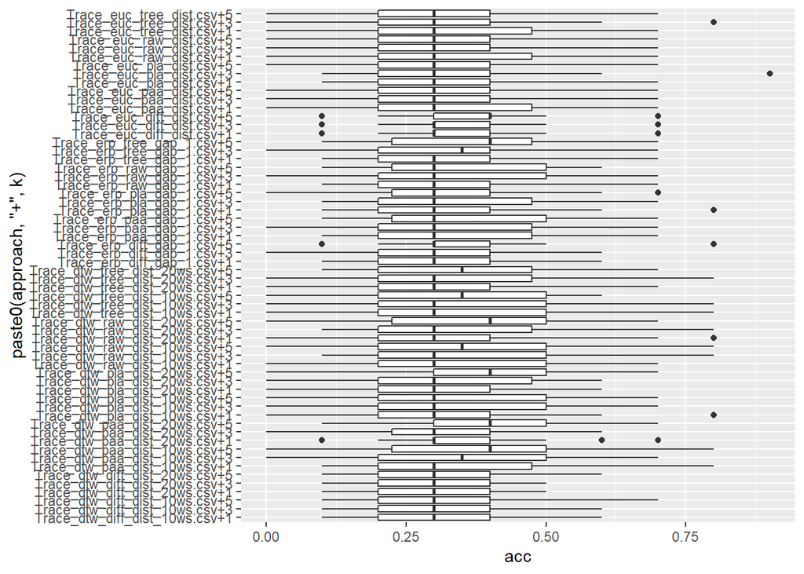

```r
require(ggplot2)
ggplot(overall_results,aes(x=paste0(approach,'+',k), y=acc)) +
geom_boxplot()+
coord_flip()
```